# Lesson1.2

BM XSTK

2026-01-29

## A. Phân bố nhiều chiều

Phân phối nhiều chiều được thiết kế để mô tả phân phối xác suất của nhiều biến ngẫu nhiên cùng một lúc. Vì các biến thường tương quan với nhau, việc khám phá chúng riêng lẻ chỉ cung cấp cái nhìn hạn chế.

### 1. Cấu trúc của dữ liệu nhiều biến

Dưới dạng hình chữ nhật được sắp xếp theo hàng và cột

```r
wine <- read.table("http://archive.ics.uci.edu/ml/machine-learning-databases/wine/wine.data", sep = ",")

# Print the first four entries
head(wine, n = 4)
```

```
##   V1    V2   V3   V4   V5  V6   V7   V8   V9  V10  V11  V12  V13  V14
## 1  1 14.23 1.71 2.43 15.6 127 2.80 3.06 0.28 2.29 5.64 1.04 3.92 1065
## 2  1 13.20 1.78 2.14 11.2 100 2.65 2.76 0.26 1.28 4.38 1.05 3.40 1050
## 3  1 13.16 2.36 2.67 18.6 101 2.80 3.24 0.30 2.81 5.68 1.03 3.17 1185
## 4  1 14.37 1.95 2.50 16.8 113 3.85 3.49 0.24 2.18 7.80 0.86 3.45 1480
```

```r
dim(wine)
```

```
## [1] 178  14
```

```r
names(wine)
```

```
##  [1] "V1"  "V2"  "V3"  "V4"  "V5"  "V6"  "V7"  "V8"  "V9"  "V10" "V11" "V12"
## [13] "V13" "V14"
```

```r
colnames(wine) <- c('Type', 'Alcohol', 'Malic', 'Ash', 'Alcalinity', 'Magnesium', 'Phenols', 'Flavanoids', 'Nonflavanoids','Proanthocyanins', 'Color', 'Hue', 'Dilution', 'Proline')

# Check the new column names
names(wine)
```

```
##  [1] "Type"            "Alcohol"         "Malic"           "Ash"
##  [5] "Alcalinity"      "Magnesium"       "Phenols"         "Flavanoids"
##  [9] "Nonflavanoids"   "Proanthocyanins" "Color"           "Hue"
## [13] "Dilution"        "Proline"
```

```r
str(wine)
```

```
## 'data.frame':    178 obs. of  14 variables:
##  $ Type           : int  1 1 1 1 1 1 1 1 1 1 ...
##  $ Alcohol        : num  14.2 13.2 13.2 14.4 13.2 ...
##  $ Malic          : num  1.71 1.78 2.36 1.95 2.59 1.76 1.87 2.15 1.64 1.35 ...
##  $ Ash            : num  2.43 2.14 2.67 2.5 2.87 2.45 2.45 2.61 2.17 2.27 ...
##  $ Alcalinity     : num  15.6 11.2 18.6 16.8 21 15.2 14.6 17.6 14 16 ...
##  $ Magnesium      : int  127 100 101 113 118 112 96 121 97 98 ...
##  $ Phenols        : num  2.8 2.65 2.8 3.85 2.8 3.27 2.5 2.6 2.8 2.98 ...
##  $ Flavanoids     : num  3.06 2.76 3.24 3.49 2.69 3.39 2.52 2.51 2.98 3.15 ...
##  $ Nonflavanoids  : num  0.28 0.26 0.3 0.24 0.39 0.34 0.3 0.31 0.29 0.22 ...
##  $ Proanthocyanins: num  2.29 1.28 2.81 2.18 1.82 1.97 1.98 1.25 1.98 1.85 ...
##  $ Color          : num  5.64 4.38 5.68 7.8 4.32 6.75 5.25 5.05 5.2 7.22 ...
##  $ Hue            : num  1.04 1.05 1.03 0.86 1.04 1.05 1.02 1.06 1.08 1.01 ...
##  $ Dilution       : num  3.92 3.4 3.17 3.45 2.93 2.85 3.58 3.58 2.85 3.55 ...
##  $ Proline        : int  1065 1050 1185 1480 735 1450 1290 1295 1045 1045 ...
```

```r
# Change the Type variable data type
wine$Type <- as.factor(wine$Type)

# Check data type/structure again
str(wine)
```

```
## 'data.frame':    178 obs. of  14 variables:
##  $ Type           : Factor w/ 3 levels "1","2","3": 1 1 1 1 1 1 1 1 1 1 ...
##  $ Alcohol        : num  14.2 13.2 13.2 14.4 13.2 ...
##  $ Malic          : num  1.71 1.78 2.36 1.95 2.59 1.76 1.87 2.15 1.64 1.35 ...
##  $ Ash            : num  2.43 2.14 2.67 2.5 2.87 2.45 2.45 2.61 2.17 2.27 ...
##  $ Alcalinity     : num  15.6 11.2 18.6 16.8 21 15.2 14.6 17.6 14 16 ...
##  $ Magnesium      : int  127 100 101 113 118 112 96 121 97 98 ...
##  $ Phenols        : num  2.8 2.65 2.8 3.85 2.8 3.27 2.5 2.6 2.8 2.98 ...
##  $ Flavanoids     : num  3.06 2.76 3.24 3.49 2.69 3.39 2.52 2.51 2.98 3.15 ...
##  $ Nonflavanoids  : num  0.28 0.26 0.3 0.24 0.39 0.34 0.3 0.31 0.29 0.22 ...
##  $ Proanthocyanins: num  2.29 1.28 2.81 2.18 1.82 1.97 1.98 1.25 1.98 1.85 ...
##  $ Color          : num  5.64 4.38 5.68 7.8 4.32 6.75 5.25 5.05 5.2 7.22 ...
##  $ Hue            : num  1.04 1.05 1.03 0.86 1.04 1.05 1.02 1.06 1.08 1.01 ...
##  $ Dilution       : num  3.92 3.4 3.17 3.45 2.93 2.85 3.58 3.58 2.85 3.55 ...
##  $ Proline        : int  1065 1050 1185 1480 735 1450 1290 1295 1045 1045 ...
```

### 2. Véc-tơ kỳ vọng và ma trận hiệp phương sai

- Đối với dữ liệu nhiều chiều, giá trị trung bình xác định vị trí của phân phối trong một không gian nhiều chiều.
- Phương sai-hiệp phương sai đo lường sự lan truyền của dữ liệu đa biến theo nhiều hướng.

```r
colMeans(wine[, 2:5])
```

```
##    Alcohol      Malic        Ash Alcalinity
##  13.000618   2.336348   2.366517  19.494944
```

```r
by(wine[2:5], wine$Type, colMeans)
```

```
## wine$Type: 1
##    Alcohol      Malic        Ash Alcalinity
##  13.744746   2.010678   2.455593  17.037288
## ------------------------------------------------------------
## wine$Type: 2
##    Alcohol      Malic        Ash Alcalinity
##  12.278732   1.932676   2.244789  20.238028
## ------------------------------------------------------------
## wine$Type: 3
##    Alcohol      Malic        Ash Alcalinity
##  13.153750   3.333750   2.437083  21.416667
```

```r
var.wine <- var(wine[2:5])
round(var.wine, 2)
```

```
##            Alcohol Malic  Ash Alcalinity
## Alcohol       0.66  0.09 0.05      -0.84
## Malic         0.09  1.25 0.05       1.08
## Ash           0.05  0.05 0.08       0.41
## Alcalinity   -0.84  1.08 0.41      11.15
```

```r
#install.packages("corrplot")
library(corrplot)
cor.wine <- cor(wine[, 2:5])
round(cor.wine, 2)
```

```
##            Alcohol Malic  Ash Alcalinity
## Alcohol       1.00  0.09 0.21      -0.31
## Malic         0.09  1.00 0.16       0.29
## Ash           0.21  0.16 1.00       0.44
## Alcalinity   -0.31  0.29 0.44       1.00
```

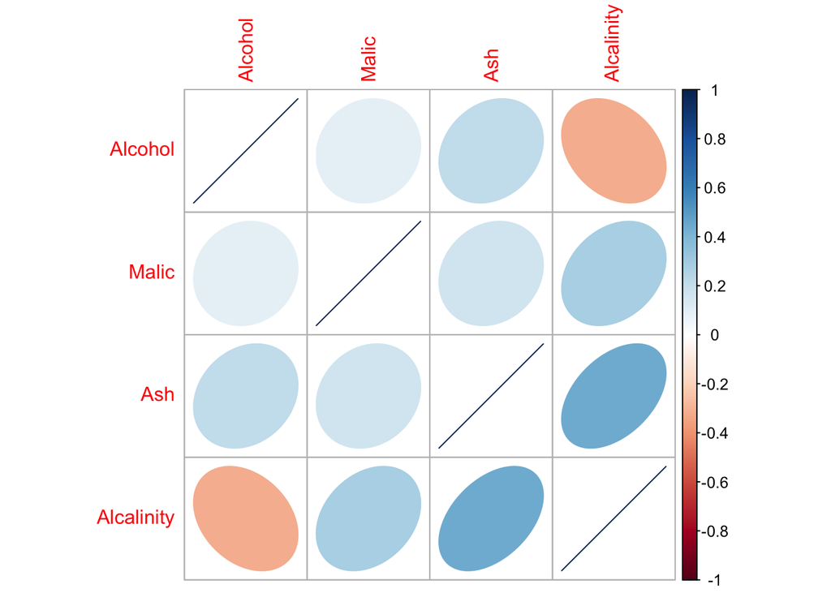

```r
corrplot(cor.wine, method = "ellipse")
```

### 3. Vẽ biểu đồ dữ liệu đa biến

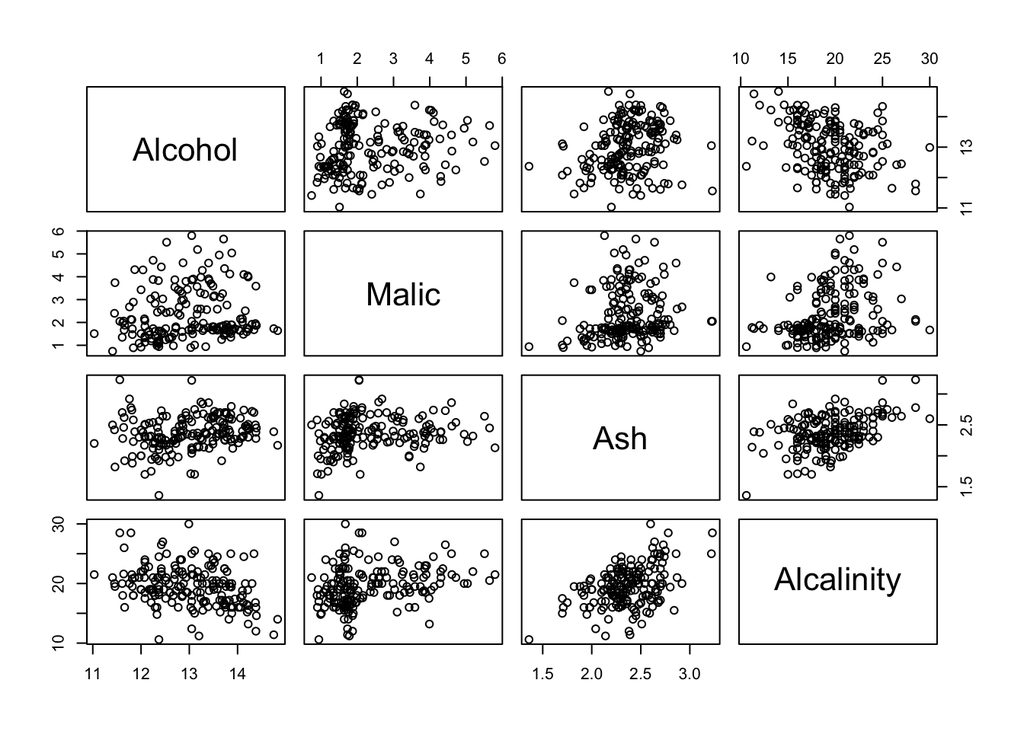

```r
library(lattice)
# Scatter plot matrix using the base R plot function
pairs(wine[,2:5])
```

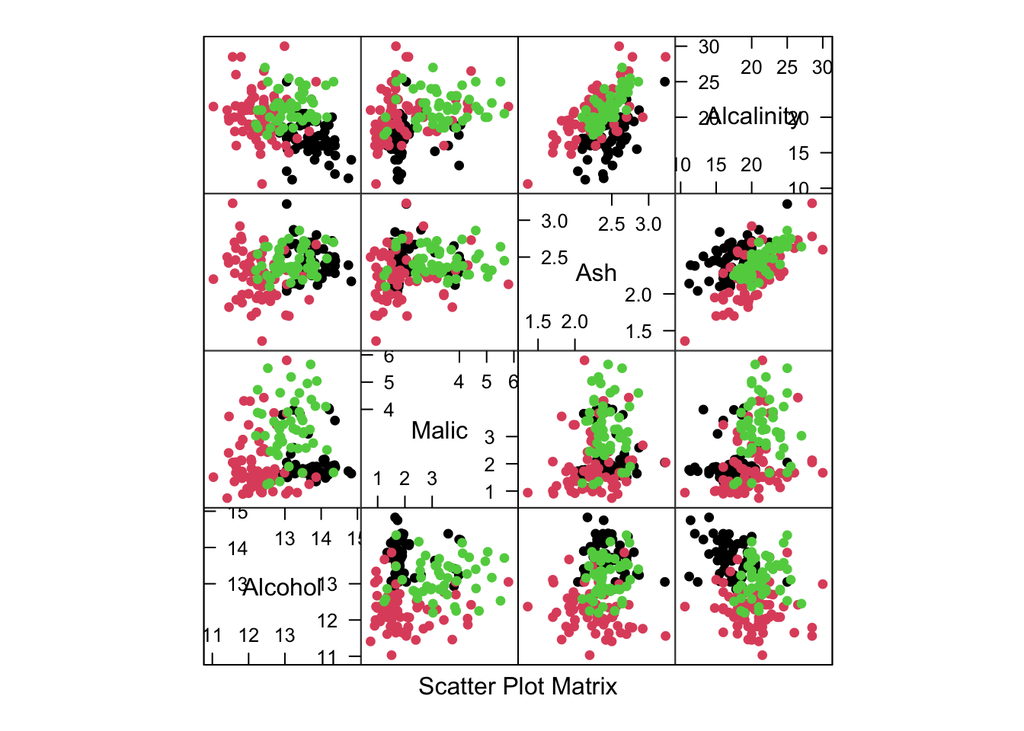

```r
# Scatter plot matrix colored by groups
splom( ~ wine[,2:5],  pch = 16, col = wine$Type)
```

```r
#install.packages(c("patchwork", "ggstats", "GGally"))
library(ggplot2)
library(GGally)
```

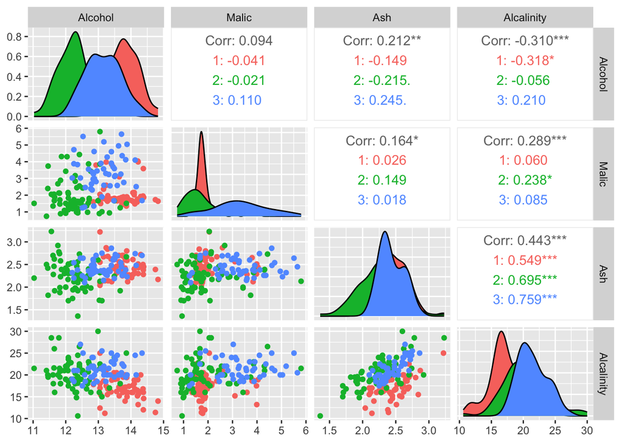

```r
# Color the points by wine type
wine.gg <- ggpairs(data = wine, mapping = aes(color = Type), columns = 2:5)
wine.gg
```

### 5. Phân bố chuẩn nhiều chiều

Nó là sự khái quát hóa của chuẩn đơn biến và được xác định bởi ma trận hiệp phương sai phương sai và vectơ kỳ vọng. Ngay cả khi tất cả các biến riêng lẻ tuân theo một chuẩn đơn biến, phân phối chung có thể không phải là một chuẩn đa biến.

```r
#install.packages("mvtnorm")
library(mvtnorm)
```

```r
mu.sim <- c(2, -2, 1)
sigma.sim <- matrix(data = c(9,5,5,5,5,3,5,3,4), nrow = 3)
# Generate 100 bivariate normal samples
multnorm.sample <- rmvnorm(n = 100, mean = mu.sim, sigma = sigma.sim)

# View the first 6 samples
head(multnorm.sample)
```

```
##           [,1]       [,2]        [,3]
## [1,] -2.837838 -4.9033280 -4.29484725
## [2,]  2.230662 -4.5136339 -0.05020505
## [3,]  1.264216 -3.8005141 -0.89281808
## [4,]  4.292475 -1.9701714  1.67096203
## [5,]  4.206360 -0.8470102  2.33942862
## [6,] -2.211091 -3.3762476 -0.95226009
```

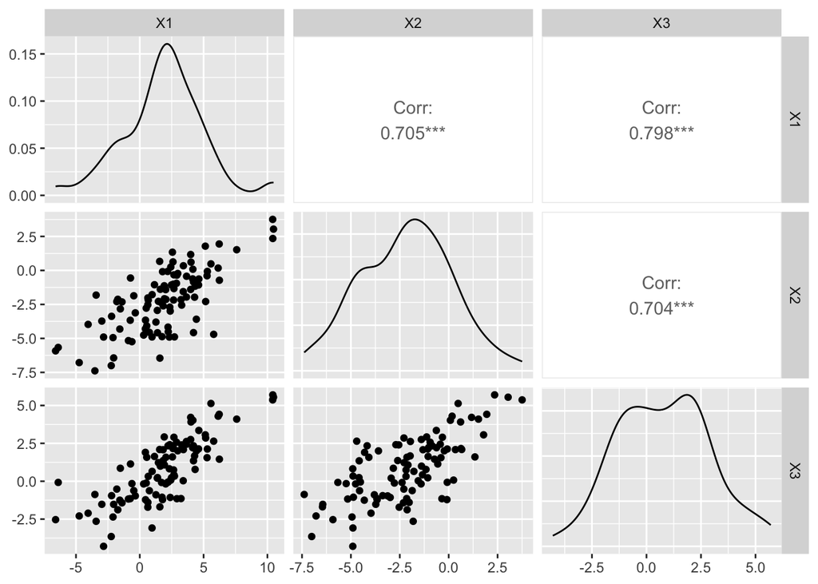

```r
ggpairs(data.frame(multnorm.sample))
```

### 6. Kiểm tra tính chuẩn của dữ liệu nhiều chiều

- Bước 1: kiểm tra từng biến trong véc-tơ ngẫu nhiên có phân bố chuẩn không? Nếu tồn tại 1 biến không có phân bố chuẩn thì kết luận luôn véc-tơ không có phân bố chuẩn nhiều chiều. Trường hợp còn lại chuyển sang bước 2.
- Bước 2: Sử dụng khoảng cách Mahalanois để kiểm tra phân bố chuẩn đồng thời của dữ liệu.

```r
candy <- read.table("~/Downloads/PTTKNC - 2023-2024/candy.txt", header = TRUE)
head(candy)
```

```
##          Name Calories Fat Satfat Carbs Sugar Sodium
## 1    100Grand      190   8      5    30    22     90
## 2 3Musketeers      240   7      5    42    36     90
## 3   5thAvenue      260  12      5    38    29    120
## 4   AlmondJoy      220  13      8    26    20     50
## 5  AndesMints      200  13     11    22    20     20
## 6    BabyRuth      275  13      7    39    32    138
```

```r
colMeans(candy[,-1])
```

```
##   Calories        Fat     Satfat      Carbs      Sugar     Sodium
## 228.473684  11.236842   6.368421  30.815789  25.526316  79.368421
```

```r
candy = candy[,-1]
```

Kiểm tra tính chuẩn bằng đồ thị QQ-plot (trực quan - vẫn nên dùng kđ shapiro.test)

```r
#install.packages("car")
library(car)
```

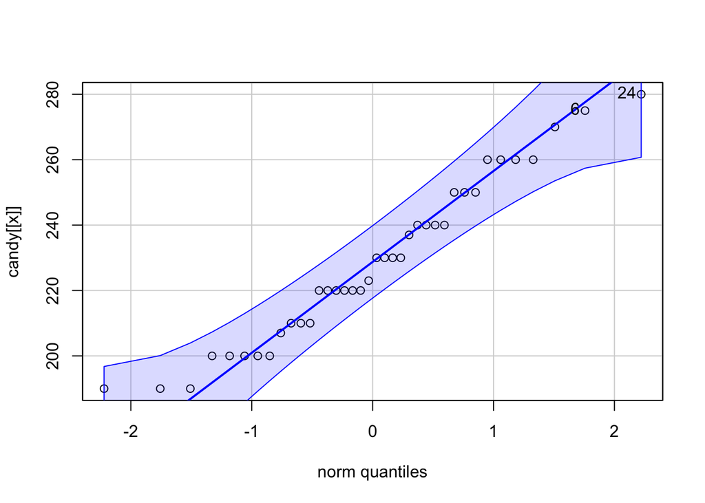

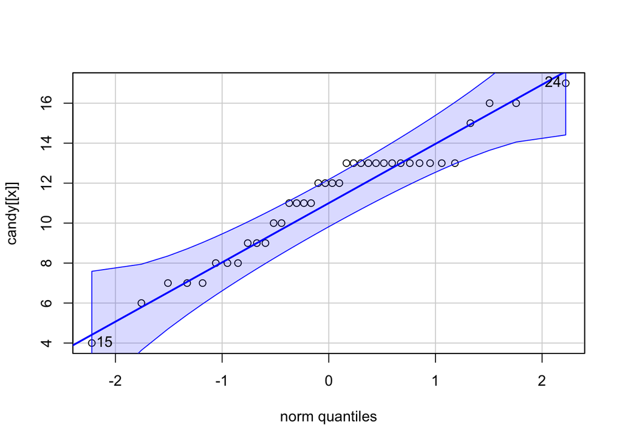

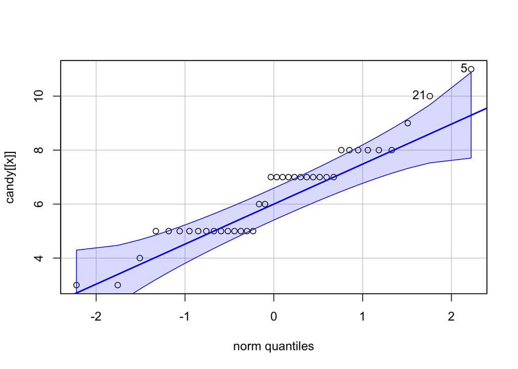

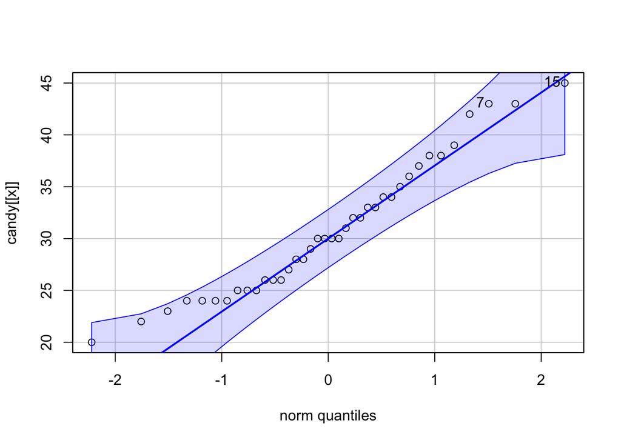

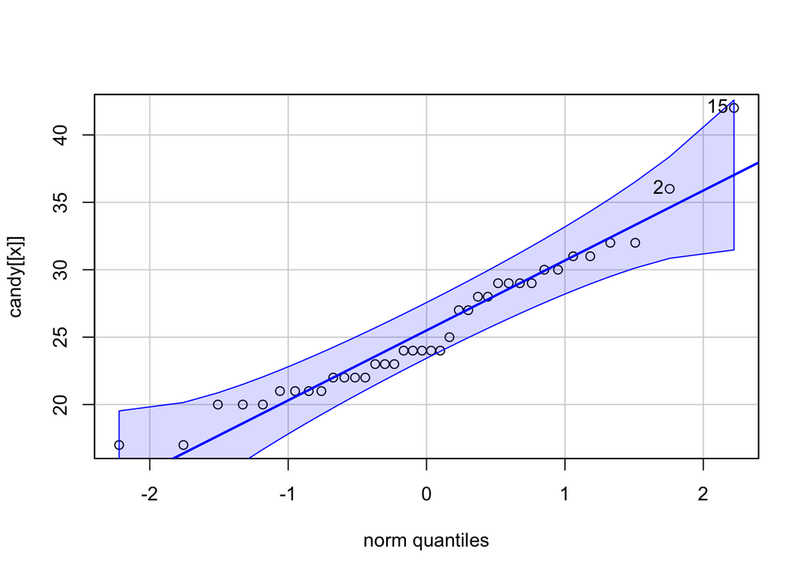

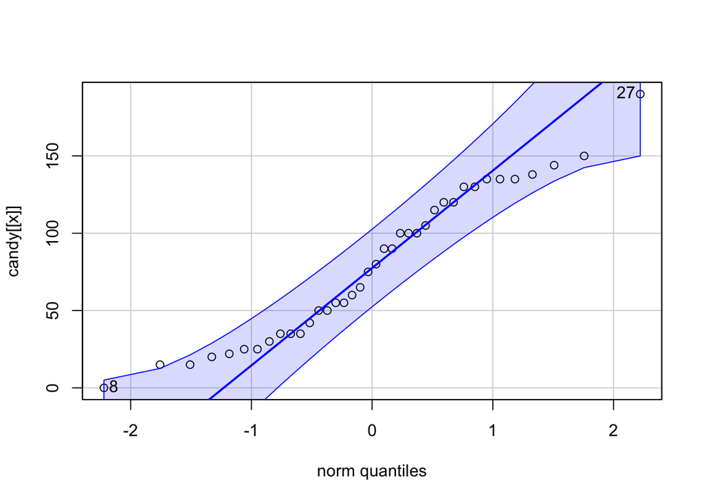

```
##      Calories Fat Satfat Carbs Sugar Sodium
## [1,]       24  15      5    15    15     27
## [2,]        6  24     21     7     2      8
```

```r
sapply(colnames(candy), function(x) {qqPlot(candy[[x]])})
```

```r
sapply(colnames(candy), function(x) {shapiro.test(candy[[x]])})
```

```
##           Calories                      Fat
## statistic 0.9592909                     0.9437532
## p.value   0.180001                      0.0555114
## method    "Shapiro-Wilk normality test" "Shapiro-Wilk normality test"
## data.name "candy[[x]]"                  "candy[[x]]"
##           Satfat                        Carbs
## statistic 0.9281287                     0.954119
## p.value   0.01752108                    0.1217529
## method    "Shapiro-Wilk normality test" "Shapiro-Wilk normality test"
## data.name "candy[[x]]"                  "candy[[x]]"
##           Sugar                         Sodium
## statistic 0.938708                      0.950255
## p.value   0.03804629                    0.09079033
## method    "Shapiro-Wilk normality test" "Shapiro-Wilk normality test"
## data.name "candy[[x]]"                  "candy[[x]]"
```

Nếu p-value < mức ý nghĩa thì là không có phân bố chuẩn một chiều.

```r
mah <- mahalanobis(candy, colMeans(candy), var(candy))
mah
```

```
##  [1]  5.1158988  4.8969585  3.2130335  2.6230218  8.6630659  5.6681202
##  [7]  9.7345727  9.9935922 10.5468399  2.3535457  8.1993676  5.6592197
## [13]  4.7721034  6.9968513 15.0393764  4.2133338  5.8251006  4.1417814
## [19]  4.0798023  2.8154453  6.6207476  3.5458813  0.6947983 14.2418951
## [25]  8.3301285  7.5091033  8.2977518  5.2620255  5.9884871  6.4641222
## [31]  5.4210736  1.6875562  2.3017187  3.0116243  2.5510894  7.1641548
## [37]  4.8855000  3.4713113
```

Do dữ liệu có 6 cột nên ta sẽ so sánh các khoảng cách Mahalanobis đã sắp xếp với phân phối khi bình phương $\mathcal{X}^2$ với 6 bậc tự do.

```r
#Sắp xếp các khoảng cách Mahalanobis
sort(mah)
```

```
##  [1]  0.6947983  1.6875562  2.3017187  2.3535457  2.5510894  2.6230218
##  [7]  2.8154453  3.0116243  3.2130335  3.4713113  3.5458813  4.0798023
## [13]  4.1417814  4.2133338  4.7721034  4.8855000  4.8969585  5.1158988
## [19]  5.2620255  5.4210736  5.6592197  5.6681202  5.8251006  5.9884871
## [25]  6.4641222  6.6207476  6.9968513  7.1641548  7.5091033  8.1993676
## [31]  8.2977518  8.3301285  8.6630659  9.7345727  9.9935922 10.5468399
## [37] 14.2418951 15.0393764
```

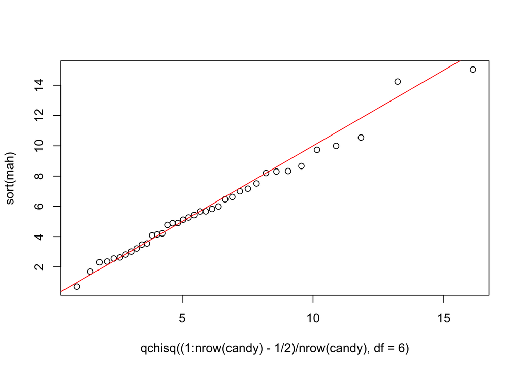

```r
#QQ-plot về khoảng cách Mahalanobis của dữ liệu
qqplot(qchisq((1:nrow(candy) - 1/2) / nrow(candy), df = 6), sort(mah))
abline(a = 0, b = 1, col = "red")
```

Một cách trực quan, từ biểu đồ này, ta có thể thấy rằng dường như các giá trị dữ liệu tuân theo phân phối chuẩn nhiều chiều.

Ta có thể kiểm tra tính chuẩn của dữ liệu bằng cách chuyển khoảng cách Mahalanobis từ các giá trị khi bình phương thành các phân vị chuẩn.

```r
shapiro.test(qnorm(pchisq(mah,6)))
```

```
##
##  Shapiro-Wilk normality test
##
## data:  qnorm(pchisq(mah, 6))
## W = 0.98968, p-value = 0.9752
```

Hàm pchisq chuyển đổi các khoảng cách Mahalanobis (mah) thành các giá trị p-value từ phân phối $\mathcal{X}^2$ tham chiếu. Sau đó qnorm biến đổi p-value thành phân vị chuẩn cần thiết để kiểm định Shapiro-Wilk. Giá trị p-value > 0.05 cho thấy rằng dữ liệu có phân phối chuẩn nhiều chiều, nhưng đây không phải là một kiểm định chính thức cho tính chuẩn đa chiều.

Cách khác, ta dùng gói lệnh mvtnormtest (nên sử dụng cách này)

```r
#install.packages("mvnormtest")
library(mvnormtest)
mshapiro.test(t(candy))
```

```
##
##  Shapiro-Wilk normality test
##
## data:  Z
## W = 0.87314, p-value = 0.0004835
```

mshapiro cần dữ liệu được sắp xếp thành các biến theo hàng và các quan sát theo cột nên ta chuyển vị ma trận dữ liệu bằng hàm t().

Giá trị p-value rất nhỏ cho thấy dữ liệu không có phân phối chuẩn nhiều chiều.

### 7. Phân bố student - t nhiều chiều

### 8. Phân bố Skewed nhiều chiều

### 9. PCA

## B. Ước lượng

### 1. Ước lượng điểm bởi phương pháp MLE

```r
# Load necessary libraries
library(ggplot2)

# Generate synthetic data from an exponential distribution
set.seed(123)
data <- rexp(100, rate = 0.1)

# Likelihood function for the exponential distribution
log_likelihood <- function(lambda) {
  sum(dexp(data, rate = lambda, log = TRUE))
}

# Maximum Likelihood Estimation using optim
result <- optim(par = 0.1, log_likelihood, method = "Brent", lower = 0.001, upper = 10)
mle_lambda <- result$par

# Print the MLE estimate
cat("Maximum Likelihood Estimate for Lambda:", mle_lambda, "\n")
```

```
## Maximum Likelihood Estimate for Lambda: 10
```

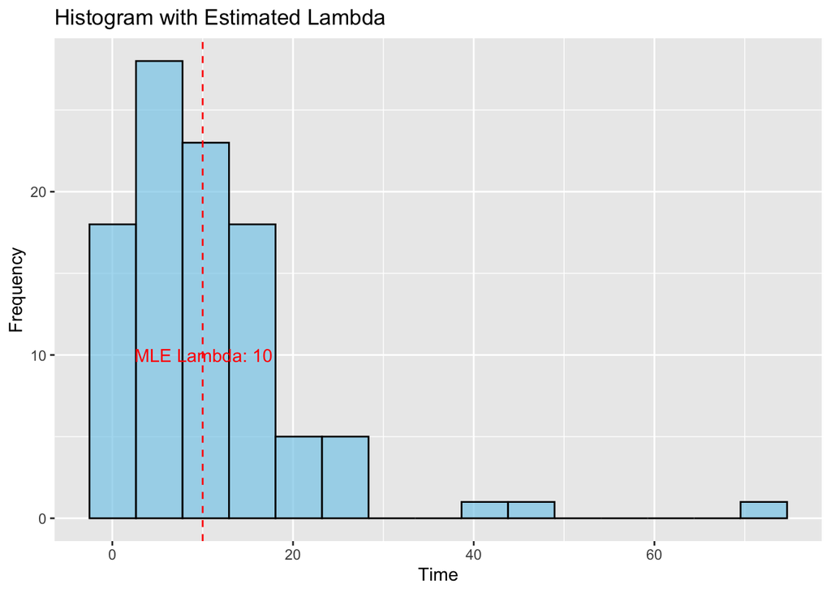

```r
# Plot the histogram of the data with the estimated lambda
ggplot(data = NULL, aes(x = data)) +
  geom_histogram(bins = 15, fill = "skyblue", color = "black", alpha = 0.7) +
  geom_vline(xintercept = mle_lambda, color = "red", linetype = "dashed") +
  annotate("text", x = mle_lambda + 0.1, y = 10,
           label = paste("MLE Lambda:", round(mle_lambda, 2)), color = "red") +
  labs(title = "Histogram with Estimated Lambda", x = "Time", y = "Frequency")
```

Sử dụng hàm optimize để ước lượng MLE.

```r
x <- mtcars$am
L <- function(p,x) prod(dbinom(x, size = 1, prob = p))
optimize(L, interval = c(0,1), x = x, maximum = TRUE)
```

```
## $maximum
## [1] 0.4062458
##
## $objective
## [1] 4.099989e-10
```

```r
minuslogL <- function(p,x){
-sum(dbinom(x, size = 1, prob = p, log = TRUE))
}
optimize(minuslogL, interval = c(0,1), x = x)
```

```
## $minimum
## [1] 0.4062525
##
## $objective
## [1] 21.61487
```

Sử dụng hàm mle có sẵn.

```r
library(stats4)

x <- PlantGrowth$weight

minuslogL <- function(mu, sigma2) {
  -sum(dnorm(x, mean = mu, sd = sqrt(sigma2), log = TRUE))
}

MaxLikeEst <- mle(minuslogL, start = list(mu = 5, sigma2 = 0.5))
MaxLikeEst
```

```
##
## Call:
## mle(minuslogl = minuslogL, start = list(mu = 5, sigma2 = 0.5))
##
## Coefficients:
##        mu    sigma2
## 5.0729848 0.4752721
```

```r
summary(MaxLikeEst)
```

```
## Maximum likelihood estimation
##
## Call:
## mle(minuslogl = minuslogL, start = list(mu = 5, sigma2 = 0.5))
##
## Coefficients:
##         Estimate Std. Error
## mu     5.0729848  0.1258666
## sigma2 0.4752721  0.1227108
##
## -2 log L: 62.82084
```

```r
mean(x); var(x)*29/30; sd(x)/sqrt(30)
```

```
## [1] 5.073
```

```
## [1] 0.475281
```

```
## [1] 0.1280195
```

### 2. Ước lượng khoảng tin cậy

Giả sử $X$ có phân bố chuẩn, hãy xây dựng khoảng tin cậy cho các tham số dựa theo các hàm có sẵn trong R của phân bố chuẩn.

### 3. Ước lượng điểm bởi phương pháp moment

```r
data(airquality)
x <- na.omit(airquality$Ozone)
length(x)
```

```
## [1] 116
```

```r
m1 <- mean(x)
m2 <- var(x)
```

```r
alpha_mom <- m1^2 / m2
beta_mom  <- m1 / m2

alpha_mom
```

```
## [1] 1.631022
```

```r
beta_mom
```

```
## [1] 0.03871466
```

```r
fit_mle <- MASS::fitdistr(x, "gamma")

fit_mle$estimate
```

```
##      shape       rate
## 1.69927902 0.04033486
```

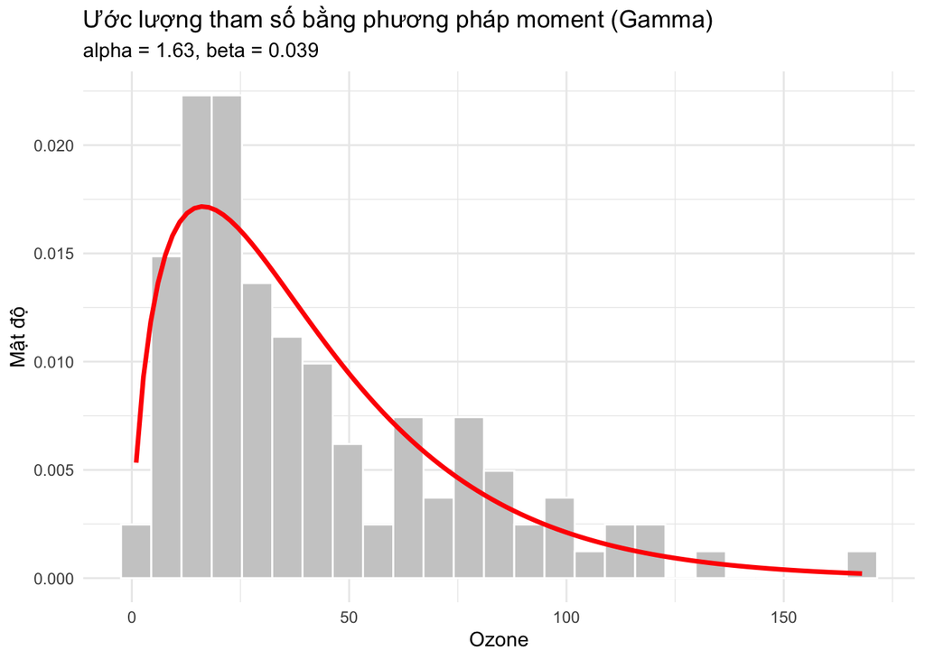

```r
library(ggplot2)
ggplot(data.frame(x = x), aes(x)) +
  geom_histogram(aes(y = after_stat(density)),
                 bins = 25,
                 fill = "grey80",
                 color = "white") +
  stat_function(
    fun = dgamma,
    args = list(shape = alpha_mom, rate = beta_mom),
    color = "red",
    linewidth = 1.2
  ) +
  labs(
    title = "Ước lượng tham số bằng phương pháp moment (Gamma)",
    subtitle = paste0("alpha = ", round(alpha_mom, 2),
                      ", beta = ", round(beta_mom, 3)),
    x = "Ozone",
    y = "Mật độ"
  ) +
  theme_minimal()
```

### 4. Ước lượng điểm bởi phương pháp bình phương tối thiểu

```r
library(ggplot2)

data(airquality)
x <- na.omit(airquality$Ozone)
```

```r
dens_emp <- density(x)

x_grid <- dens_emp$x
f_emp  <- dens_emp$y
```

```r
LS_gamma <- function(par) {
  shape <- par[1]
  rate  <- par[2]

  if (shape <= 0 || rate <= 0) return(Inf)

  f_theo <- dgamma(x_grid, shape = shape, rate = rate)
  sum((f_emp - f_theo)^2)
}
```

```r
opt_ls <- optim(
  par = c(5, 0.1),
  fn = LS_gamma,
  method = "L-BFGS-B",
  lower = c(1e-6, 1e-6)
)

shape_ls <- opt_ls$par[1]
rate_ls  <- opt_ls$par[2]
```

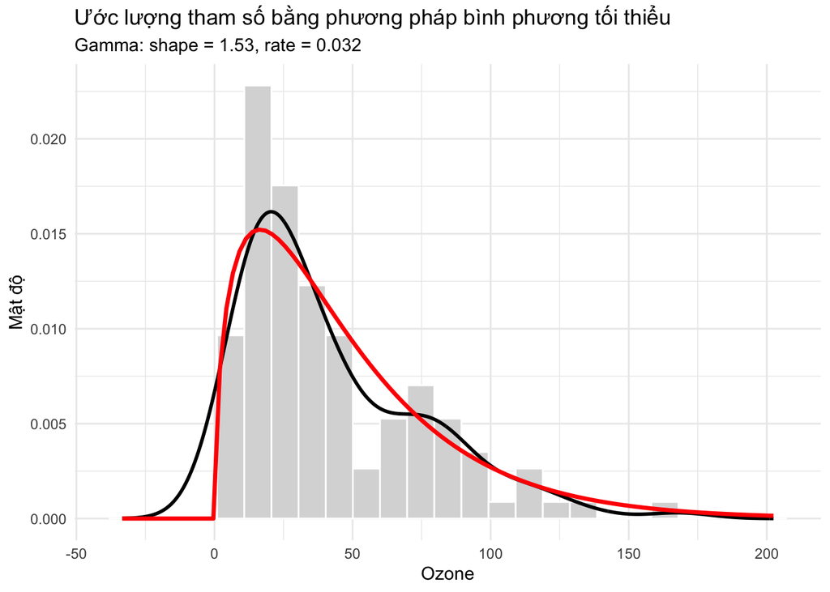

```r
ggplot(data.frame(x = x), aes(x)) +
  geom_histogram(aes(y = after_stat(density)),
                 bins = 25,
                 fill = "grey85",
                 color = "white") +
  geom_line(
    data = data.frame(x = x_grid, y = f_emp),
    aes(x, y),
    color = "black",
    linewidth = 1
  ) +
  stat_function(
    fun = dgamma,
    args = list(shape = shape_ls, rate = rate_ls),
    color = "red",
    linewidth = 1.2
  ) +
  labs(
    title = "Ước lượng tham số bằng phương pháp bình phương tối thiểu",
    subtitle = paste0("Gamma: shape = ", round(shape_ls,2),
                      ", rate = ", round(rate_ls,3)),
    x = "Ozone",
    y = "Mật độ"
  ) +
  theme_minimal()
```

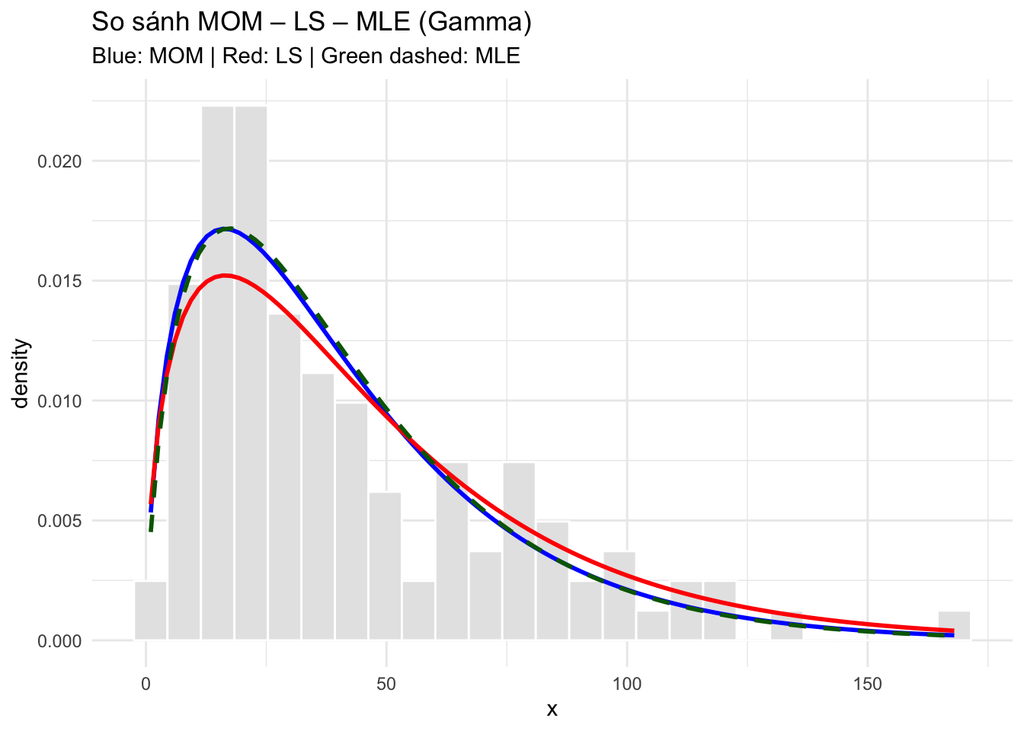

```r
library(MASS)

# MOM
m1 <- mean(x); m2 <- var(x)
shape_mom <- m1^2 / m2
rate_mom  <- m1 / m2

# MLE
fit_mle <- fitdistr(x, "gamma")

ggplot(data.frame(x = x), aes(x)) +
  geom_histogram(aes(y = after_stat(density)),
                 bins = 25,
                 fill = "grey90",
                 color = "white") +
  stat_function(fun = dgamma,
                args = list(shape = shape_mom, rate = rate_mom),
                color = "blue", linewidth = 1) +
  stat_function(fun = dgamma,
                args = list(shape = shape_ls, rate = rate_ls),
                color = "red", linewidth = 1) +
  stat_function(fun = dgamma,
                args = list(shape = fit_mle$estimate["shape"],
                            rate  = fit_mle$estimate["rate"]),
                color = "darkgreen",
                linetype = "dashed",
                linewidth = 1) +
  labs(
    title = "So sánh MOM – LS – MLE (Gamma)",
    subtitle = "Blue: MOM | Red: LS | Green dashed: MLE"
  ) +
  theme_minimal()
```

### 5. Ước lượng vững

### 6. Ước lượng hiệu quả